# Project1_AirTransportation

Data Set - http://www.stat.ufl.edu/~winner/data/airq402.dat

Data Description - http://www.stat.ufl.edu/~winner/data/airq402.txt

Assignment Expectations/Steps -

> - Import and store the data in a data frame. (2.5 points)
> - Remove the outliers from the data (5 points)
> - Treat “Average Fare” – 3rdColumn as your Dependent Variable and Rest of the columns as Independent Variable. (2.5 points)
> - Drop the independent variables which has less than 0.1 correlation with the dependent variable (5 points)
> - Create scatter Plot of Independent Variable vs Dependent Variable. (2.5 points)
> - Divide the data set into training and test data set and build a Multiple Linear Regression model. (5 points)
> - Print the coefficients & intercepts of the linear regression model (5 points)
> - Print the accuracy of the overall model (2.5 points)

```python
# Numerical libraries
import numpy as np

# Import Linear Regression machine learning library
from sklearn.linear_model import LinearRegression

# to handle data in form of rows and columns
import pandas as pd

# importing ploting libraries
import matplotlib.pyplot as plt

#importing seaborn for statistical plots
import seaborn as sns

from sklearn.model_selection import train_test_split
```

```python
columns =  ['CITY_FROM','CITY_TO','AVERAGE_FARE','DISTANCE','AVERAGE_WEEKLY_PASSENGERS','MARKET_LEADING_AIRLINE',
           'MARKET_SHARE','AVERAGE_FARE_LEADING','LOW_PRICE_AIRLINE','MARKET_SHARE_LOWER','PRICE']
#Read a table of fixed-width formatted lines into DataFrame.

airq_df = pd.read_fwf('airq402.dat',names=columns)
```

**Performing EDA**

```python
airq_df.shape
```

```
(1000, 11)
```

```python
airq_df.head()
```

|  | CITY_FROM | CITY_TO | AVERAGE_FARE | DISTANCE | AVERAGE_WEEKLY_PASSENGERS | MARKET_LEADING_AIRLINE | MARKET_SHARE | AVERAGE_FARE_LEADING | LOW_PRICE_AIRLINE | MARKET_SHARE_LOWER | PRICE |
| --- | --- | --- | --- | --- | --- | --- | --- | --- | --- | --- | --- |
| 0 | CAK | ATL | 114.47 | 528 | 424.56 | FL | 70.19 | 111.03 | FL | 70.19 | 111.03 |
| 1 | CAK | MCO | 122.47 | 860 | 276.84 | FL | 75.10 | 123.09 | DL | 17.23 | 118.94 |
| 2 | ALB | ATL | 214.42 | 852 | 215.76 | DL | 78.89 | 223.98 | CO | 2.77 | 167.12 |
| 3 | ALB | BWI | 69.40 | 288 | 606.84 | WN | 96.97 | 68.86 | WN | 96.97 | 68.86 |
| 4 | ALB | ORD | 158.13 | 723 | 313.04 | UA | 39.79 | 161.36 | WN | 15.34 | 145.42 |

```python
airq_df.info()
```

```
<class 'pandas.core.frame.DataFrame'>
RangeIndex: 1000 entries, 0 to 999
Data columns (total 11 columns):
CITY_FROM                    1000 non-null object
CITY_TO                      1000 non-null object
AVERAGE_FARE                 1000 non-null float64
DISTANCE                     1000 non-null int64
AVERAGE_WEEKLY_PASSENGERS    1000 non-null float64
MARKET_LEADING_AIRLINE       1000 non-null object
MARKET_SHARE                 1000 non-null float64
AVERAGE_FARE_LEADING         1000 non-null float64
LOW_PRICE_AIRLINE            1000 non-null object
MARKET_SHARE_LOWER           1000 non-null float64
PRICE                        1000 non-null float64
dtypes: float64(6), int64(1), object(4)
memory usage: 86.0+ KB
```

> - There are no null values

```python
airq_df.describe().T
```

|  | count | mean | std | min | 25% | 50% | 75% | max |
| --- | --- | --- | --- | --- | --- | --- | --- | --- |
| AVERAGE_FARE | 1000.0 | 163.37542 | 55.365470 | 50.52 | 125.9750 | 161.345 | 197.3925 | 401.23 |
| DISTANCE | 1000.0 | 1056.97300 | 643.203251 | 108.00 | 553.5000 | 919.000 | 1452.5000 | 2724.00 |
| AVERAGE_WEEKLY_PASSENGERS | 1000.0 | 672.27914 | 766.519254 | 181.41 | 257.1975 | 404.780 | 769.9125 | 8950.76 |
| MARKET_SHARE | 1000.0 | 60.12859 | 19.367779 | 17.68 | 46.5100 | 59.240 | 73.5100 | 100.00 |
| AVERAGE_FARE_LEADING | 1000.0 | 166.64756 | 62.660140 | 50.52 | 124.0850 | 161.400 | 202.9775 | 490.03 |
| MARKET_SHARE_LOWER | 1000.0 | 34.55148 | 27.096999 | 1.06 | 13.1950 | 26.140 | 52.9725 | 100.00 |
| PRICE | 1000.0 | 143.19309 | 47.229184 | 49.61 | 113.7675 | 137.825 | 168.5300 | 387.94 |

```python
airq_df.dtypes
```

```
CITY_FROM                     object
CITY_TO                       object
AVERAGE_FARE                 float64
DISTANCE                       int64
AVERAGE_WEEKLY_PASSENGERS    float64
MARKET_LEADING_AIRLINE        object
MARKET_SHARE                 float64
AVERAGE_FARE_LEADING         float64
LOW_PRICE_AIRLINE             object
MARKET_SHARE_LOWER           float64
PRICE                        float64
dtype: object
```

**Checking for Unique categorical values**

```python
airq_df.select_dtypes(include=['object']).nunique()
```

```
CITY_FROM                 90
CITY_TO                   85
MARKET_LEADING_AIRLINE    16
LOW_PRICE_AIRLINE         19
dtype: int64
```

```python
total_city = airq_df.CITY_FROM.append(airq_df.CITY_TO)
total_airline = airq_df.MARKET_LEADING_AIRLINE.append(airq_df.LOW_PRICE_AIRLINE)
print('Total unique locations: {}'.format(total_city.nunique()))
print('Total unique airlines: {}'.format(total_airline.nunique()))
```

```
Total unique locations: 104
Total unique airlines: 19
```

> **We should not go for One-Hot Encoding for locations as it will increase our dimension and make our model too complex or we say curse of dimensionality**

**Q2: Remove the outliers from the data**

> - **To check for outliers we first plot them**

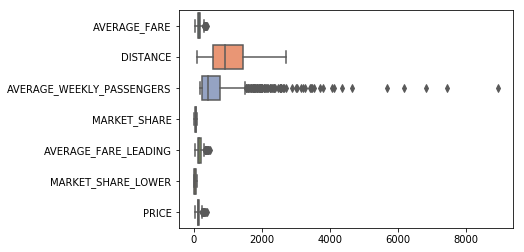

```python
sns.boxplot(data=airq_df, orient="h", palette="Set2")
```

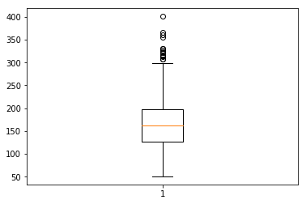

```python
plt.boxplot(airq_df['AVERAGE_FARE'])
plt.show()
```

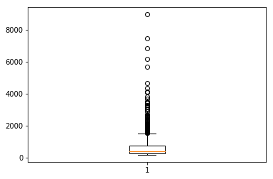

```python
plt.boxplot(airq_df['AVERAGE_WEEKLY_PASSENGERS'])
plt.show()
```

**Removing the outliers from the data**

```python
Q3 = airq_df.quantile(0.75)
Q1 = airq_df.quantile(0.25)
airq_iqr = Q3 - Q1
mini = Q1 - 1.5*airq_iqr
maxi = Q3 + 1.5*airq_iqr
```

```python
airq_iqr
```

```
AVERAGE_FARE                  71.4175
DISTANCE                     899.0000
AVERAGE_WEEKLY_PASSENGERS    512.7150
MARKET_SHARE                  27.0000
AVERAGE_FARE_LEADING          78.8925
MARKET_SHARE_LOWER            39.7775
PRICE                         54.7625
dtype: float64
```

```python
airq_df_iqr_columns = (airq_iqr.index)
airq_df_iqr_columns
```

```
Index(['AVERAGE_FARE', 'DISTANCE', 'AVERAGE_WEEKLY_PASSENGERS', 'MARKET_SHARE',
       'AVERAGE_FARE_LEADING', 'MARKET_SHARE_LOWER', 'PRICE'],
      dtype='object')
```

```python
airq_df_updated = airq_df[airq_df_iqr_columns]
airq_df_updated = airq_df_updated[(airq_df_updated > mini) & (airq_df_updated < maxi)].dropna()
```

```python
airq_df_updated.info()
```

```
<class 'pandas.core.frame.DataFrame'>
Int64Index: 885 entries, 0 to 999
Data columns (total 7 columns):
AVERAGE_FARE                 885 non-null float64
DISTANCE                     885 non-null int64
AVERAGE_WEEKLY_PASSENGERS    885 non-null float64
MARKET_SHARE                 885 non-null float64
AVERAGE_FARE_LEADING         885 non-null float64
MARKET_SHARE_LOWER           885 non-null float64
PRICE                        885 non-null float64
dtypes: float64(6), int64(1)
memory usage: 55.3 KB
```

```python
airq_df_updated.describe().T
```

|  | count | mean | std | min | 25% | 50% | 75% | max |
| --- | --- | --- | --- | --- | --- | --- | --- | --- |
| AVERAGE_FARE | 885.0 | 160.292068 | 48.468895 | 50.52 | 126.60 | 160.71 | 194.05 | 288.58 |
| DISTANCE | 885.0 | 1039.383051 | 615.224361 | 108.00 | 564.00 | 914.00 | 1381.00 | 2724.00 |
| AVERAGE_WEEKLY_PASSENGERS | 885.0 | 499.132644 | 327.573566 | 181.41 | 249.02 | 372.93 | 644.56 | 1519.89 |
| MARKET_SHARE | 885.0 | 60.636938 | 19.361447 | 17.68 | 47.02 | 59.75 | 74.66 | 100.00 |
| AVERAGE_FARE_LEADING | 885.0 | 162.589051 | 53.288002 | 50.52 | 125.59 | 160.74 | 198.47 | 315.86 |
| MARKET_SHARE_LOWER | 885.0 | 34.373028 | 27.183305 | 1.06 | 13.06 | 26.25 | 52.93 | 100.00 |
| PRICE | 885.0 | 140.431073 | 39.849789 | 50.52 | 115.11 | 138.02 | 166.26 | 250.02 |

**Q3 : Treat “Average Fare” – 3rdColumn as your Dependent Variable and Rest of the columns as Independent Variable**

```python
# Seperating Dependent or Target column from other
X = airq_df_updated.drop('AVERAGE_FARE',axis=1)
Y = airq_df_updated['AVERAGE_FARE']
```

**Q4 :Drop the independent variables which has less than 0.1 correlation with the dependent variable**

```python
airq_df_updated.corr()
```

|  | AVERAGE_FARE | DISTANCE | AVERAGE_WEEKLY_PASSENGERS | MARKET_SHARE | AVERAGE_FARE_LEADING | MARKET_SHARE_LOWER | PRICE |
| --- | --- | --- | --- | --- | --- | --- | --- |
| AVERAGE_FARE | 1.000000 | 0.522650 | -0.197005 | -0.207955 | 0.979713 | -0.493555 | 0.840993 |
| DISTANCE | 0.522650 | 1.000000 | -0.129632 | -0.547952 | 0.489721 | -0.361519 | 0.539894 |
| AVERAGE_WEEKLY_PASSENGERS | -0.197005 | -0.129632 | 1.000000 | 0.021769 | -0.163736 | 0.076176 | -0.209018 |
| MARKET_SHARE | -0.207955 | -0.547952 | 0.021769 | 1.000000 | -0.193382 | 0.281182 | -0.314555 |
| AVERAGE_FARE_LEADING | 0.979713 | 0.489721 | -0.163736 | -0.193382 | 1.000000 | -0.519442 | 0.794157 |
| MARKET_SHARE_LOWER | -0.493555 | -0.361519 | 0.076176 | 0.281182 | -0.519442 | 1.000000 | -0.260912 |
| PRICE | 0.840993 | 0.539894 | -0.209018 | -0.314555 | 0.794157 | -0.260912 | 1.000000 |

```python
airq_df_updated.corr()['AVERAGE_FARE']
```

```
AVERAGE_FARE                 1.000000
DISTANCE                     0.522650
AVERAGE_WEEKLY_PASSENGERS   -0.197005
MARKET_SHARE                -0.207955
AVERAGE_FARE_LEADING         0.979713
MARKET_SHARE_LOWER          -0.493555
PRICE                        0.840993
Name: AVERAGE_FARE, dtype: float64
```

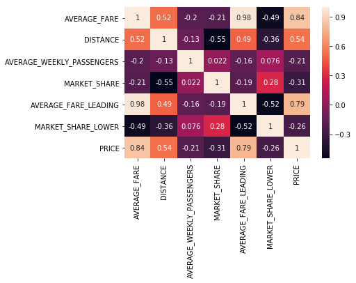

```python
sns.heatmap(airq_df_updated.corr(), annot=True)
```

> **All the columns have corr > 0.1 or corr < -0.1 so no need to drop any column**

**Q5:Create scatter Plot of Independent Variable vs Dependent Variable. (2.5 points)**

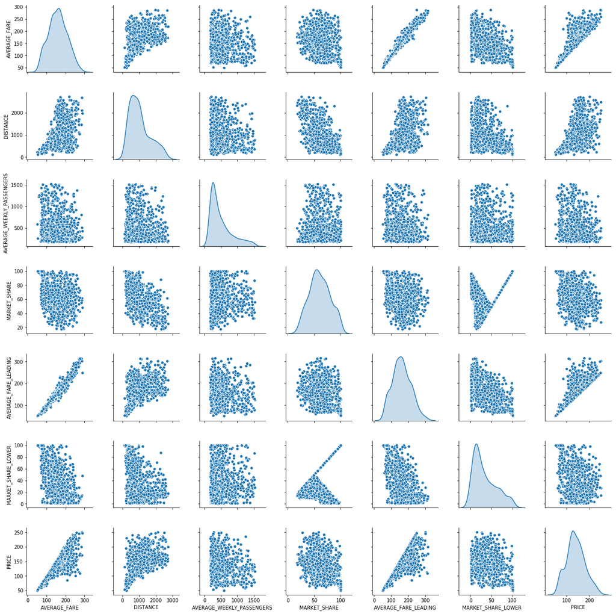

```python
sns.pairplot(airq_df_updated, diag_kind='kde')
```

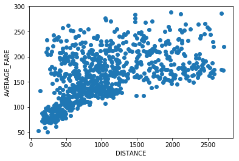

```python
plt.scatter(x="DISTANCE", y="AVERAGE_FARE", data=airq_df_updated)
plt.xlabel('DISTANCE')
plt.ylabel('AVERAGE_FARE')
```

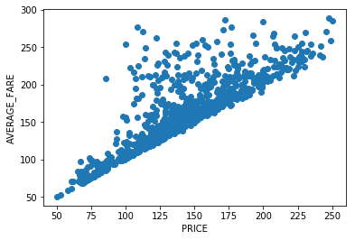

```python
plt.scatter(x="PRICE", y="AVERAGE_FARE", data=airq_df_updated)
plt.xlabel('PRICE')
plt.ylabel('AVERAGE_FARE')
```

**Price is highly corelated with Average Fare**

> **Q6 :Divide the data set into training and test data set and build a Multiple Linear Regression model**

```python
# Split X and y into training and test set in 75:25 ratio

X_train, X_test, y_train, y_test = train_test_split(X, Y, test_size=0.25, random_state=1)
```

```python
regression_model = LinearRegression()
regression_model.fit(X_train, y_train)
```

```
LinearRegression(copy_X=True, fit_intercept=True, n_jobs=None, normalize=False)
```

> **Q7 :Print the coefficients & intercepts of the linear regression model**

```python
# The coefficients for each of the independent attributes

for idx, column in enumerate(X.columns) :
    print("The coefficient for {} is {}".format(column,regression_model.coef_[idx]))
```

```
The coefficient for DISTANCE is 0.0029050601559945976
The coefficient for AVERAGE_WEEKLY_PASSENGERS is -0.0036000963955034604
The coefficient for MARKET_SHARE is 0.08469292566835171
The coefficient for AVERAGE_FARE_LEADING is 0.7316262128158858
The coefficient for MARKET_SHARE_LOWER is -0.030826618625306293
The coefficient for PRICE is 0.23035474647497675
```

```python
# The intercept for the model

intercept = regression_model.intercept_

print("The intercept for our model is {}".format(intercept))
```

```
The intercept for our model is 3.415263143189776
```

```python
#Model can be written as
model = 'AVERAGE_FARE = '+ str(intercept)+' + '
for idx, column in enumerate(X.columns) :
    data = ("{} * {} + ".format(column,regression_model.coef_[idx]))
    model = model + data
print(model)
```

```
AVERAGE_FARE = 3.415263143189776 + DISTANCE * 0.0029050601559945976 + AVERAGE_WEEKLY_PASSENGERS * -0.0036000963955034604 + MARKET_SHARE * 0.08469292566835171 + AVERAGE_FARE_LEADING * 0.7316262128158858 + MARKET_SHARE_LOWER * -0.030826618625306293 + PRICE * 0.23035474647497675 +
```

> **Print the accuracy of the overall model**

```python
accuracy = regression_model.score(X_test, y_test)
print("The accuracy for our model is {}".format(accuracy))
```

```
The accuracy for our model is 0.9736359705146775
```

```python
#Building model with OLS Method
```

```python
import statsmodels.api as sm
# Fit and make the predictions by the model
model = sm.OLS(y_train, X_train).fit()
predictions = model.predict(X_test)

# Print out the statistics
model.summary()
```

OLS Regression Results

| Dep. Variable: | AVERAGE_FARE | R-squared (uncentered): | 0.998 |
| --- | --- | --- | --- |
| Model: | OLS | Adj. R-squared (uncentered): | 0.998 |
| Method: | Least Squares | F-statistic: | 4.568e+04 |
| Date: | Sat, 17 Aug 2019 | Prob (F-statistic): | 0.00 |
| Time: | 18:48:02 | Log-Likelihood: | -2333.3 |
| No. Observations: | 663 | AIC: | 4679. |
| Df Residuals: | 657 | BIC: | 4706. |
| Df Model: | 6 |  |  |
| Covariance Type: | nonrobust |  |  |

|  | coef | std err | t | P>\|t\| | [0.025 | 0.975] |
| --- | --- | --- | --- | --- | --- | --- |
| DISTANCE | 0.0033 | 0.001 | 5.033 | 0.000 | 0.002 | 0.005 |
| AVERAGE_WEEKLY_PASSENGERS | -0.0030 | 0.001 | -3.280 | 0.001 | -0.005 | -0.001 |
| MARKET_SHARE | 0.1057 | 0.015 | 6.992 | 0.000 | 0.076 | 0.135 |
| AVERAGE_FARE_LEADING | 0.7335 | 0.013 | 58.488 | 0.000 | 0.709 | 0.758 |
| MARKET_SHARE_LOWER | -0.0247 | 0.015 | -1.673 | 0.095 | -0.054 | 0.004 |
| PRICE | 0.2364 | 0.015 | 15.542 | 0.000 | 0.207 | 0.266 |

| Omnibus: | 145.433 | Durbin-Watson: | 2.013 |
| --- | --- | --- | --- |
| Prob(Omnibus): | 0.000 | Jarque-Bera (JB): | 613.900 |
| Skew: | 0.942 | Prob(JB): | 4.94e-134 |
| Kurtosis: | 7.322 | Cond. No. | 91.2 |

Warnings:  
[1] Standard Errors assume that the covariance matrix of the errors is correctly specified.

**R-squared is 0.998**

**Adj. R-squared is 0.998**